Ian Faul, Matthew Vuong

# **Predicting native languages of adult English learners from proficiency test performance**

[Link to our website](https://ifaul.github.io/)

[Link to our GitHub](https://github.com/ifaul/ifaul.github.io)

[Link to CSV file in Drive](https://drive.google.com/file/d/1LJg6wTE_rl3WXP5lOFRoCuatc1WZjEQm/view?usp=share_link)

```python
import pandas as pd
import numpy as np
import matplotlib.pyplot as plt
import string
import re

pd.options.mode.copy_on_write = True
np.random.seed(1)
```

```python
from google.colab import drive
drive.mount('/content/drive')
%cd /content/drive/MyDrive/ColabNotebooks
```

```
/content/drive/MyDrive/ColabNotebooks
```

```python
%%shell
#jupyter nbconvert --to html /content/drive/MyDrive/ColabNotebooks/lang_predict_final.ipynb
```

# **Project Goals**

How humans acquire new languages, and why some people are better at it than others, remains a remarkably mysterious question. While it is well-known that children are the most efficient language learners and that language-learning ability declines with age, the specific factors contributing to different language learning outcomes in adulthood are more complicated. Here, we plan on using a large dataset of close to 650,000 individuals to disentangle some of these factors. In particular, we are curious to see whether there are any patterns in performance on test questions among adult English learners across various linguistic groups. In addition, we aim to determine whether adult native speakers to languages more grammatically different from English perform systematically worse than speakers of grammatically similar languages. While the original study associated with this dataset ([Hartshorne et al, 2018](https://pubmed.ncbi.nlm.nih.gov/29729947/)) examined differences in learning curves for speakers of languages of different official genuses, we will group languages based only on grammatical similarity.

**Supplementary information**

[A critical period for second language acquisition: Evidence from 2/3 million English speakers](https://pubmed.ncbi.nlm.nih.gov/29729947/)

[Affecting factors in second language learning](https://pubmed.ncbi.nlm.nih.gov/16177934/)

[A Review of the Role of Cross-Language Similarity in L2 (Morpho)Syntactic Processing as Revealed by fMRI and ERP Methods](https://www.cambridge.org/core/journals/studies-in-second-language-acquisition/article/abs/across-languages-space-and-time/A6AE90F7B8770553BF59F149426B05FC)

# **Speakers dataset**

### **ETL**

We came across this dataset in the "Data Is Plural" archive and downloaded it from [OSF](https://osf.io/pyb8s/wiki/home/). We considered several similar datasets for this project, but this one stood out due to the large number of variables and observations, as well as its being associated with a study whose conclusions we could build on. The original dataset included the following variables:

**id** Unique subject ID

**date** Date at start of experiment

**time** Time at start of experiment

**gender**

**age**

**natlangs** List of subject's native languages

**primelangs** List of subject's primary language now

**dyslexia** Did subject report difficulty with reading?

**psychiatric** Did subject report any psychiatric disorders

**education** highest level of education

**Eng_start** age at start of English learning

**Eng_country_yrs** number of years living in English-speaking country

**house_Eng** subject lives with any native English speakers?

**dictionary** subject reported using a dictionary to complete experiment

**already_participated** Subject reported prior participation in experiment

**countries** countries lived in

**currcountry** country currently lived in

**US_region** regions of USA lived in

**UK_region** regions of UK lived in

**Can_region** regions of Canada lived in

**Ebonics** speaker of Ebonics?

**Ir_region** county of Ireland lived in

**UK_constituency** constituency of UK lived in

**nat_Eng** native speaker of English

**lived_Eng_per** Percentage of years speaking English that lived in English-speaking country.

**Eng_little** values are monoeng (native speaker of English only), bileng (native speaker of English + at least one other lang), lot (immersion learner), little (non-immersion learner).

**q1, q2, etc.** test questions, with subparts

**correct** percentage of critical items correct

**elogit** elogit of correct (not sure what this means)

In the following section, we remove variables likely of little relevance, create new columns to more easily access information separated by commas in individual cells, make values within columns consistent and of the correct data type, and lastly, tidy it up.

```python
df_lang = pd.read_csv('data.csv')
df_lang.head()
```

|  | Unnamed: 0 | id | date | time | gender | age | natlangs | primelangs | dyslexia | psychiatric | ... | q34_6 | q34_8 | q35_1 | q35_2 | q35_4 | q35_5 | q35_7 | q35_8 | correct | elogit |
| --- | --- | --- | --- | --- | --- | --- | --- | --- | --- | --- | --- | --- | --- | --- | --- | --- | --- | --- | --- | --- | --- |
| 0 | 1 | 2.0 | 2014-05-29 | 01:00:55 | male | 31 | English | English | 0 | 0 | ... | 1 | 1 | 1 | 1 | 1 | 1 | 1 | 1 | 0.978947 | 3.621671 |
| 1 | 2 | 3.0 | 2014-05-29 | 01:01:03 | male | 30 | English | English | 0 | 1 | ... | 1 | 1 | 1 | 1 | 1 | 1 | 1 | 1 | 1.000000 | 5.252273 |
| 2 | 3 | 3.0 | 2014-05-29 | 01:01:03 | male | 30 | English | English | 0 | 1 | ... | 1 | 1 | 1 | 1 | 1 | 1 | 1 | 1 | 1.000000 | 5.252273 |
| 3 | 4 | 4.0 | 2014-05-29 | 01:01:13 | male | 19 | English | English | 0 | 0 | ... | 1 | 1 | 1 | 1 | 1 | 0 | 1 | 1 | 0.905263 | 2.208853 |
| 4 | 5 | 5.0 | 2014-05-29 | 01:01:19 | male | 20 | Chinese/Mandarin, English | Chinese/Mandarin, English | 0 | 0 | ... | 1 | 1 | 1 | 1 | 1 | 0 | 1 | 1 | 0.947368 | 2.800602 |

5 rows × 128 columns

```python
# Remove unnecessary variables
df_lang.drop(columns=['Unnamed: 0', 'date', 'time', 'US_region', 'UK_region',
                      'Can_region', 'Ir_region', 'UK_constituency', 'tests'], inplace=True)

# Remove strange values in some variables
df_lang['education'].unique() # There are some crazy values in here!

def replace_school_with_NAN(entry, allowed_list):
    if entry not in allowed_list:
        return np.nan
    return entry

# These appear to be the original choices offered in the questionnaire.
allowed_list = ['Graduate Degree', 'Undergraduate Degree (3-5 years higher ed)',
                'Some Undergrad (higher ed)', 'High School Degree (12-13 years)',
                'Some Graduate School', 'Didn''t Finish High School (less than 13 years ed)']

df_lang['education'] = df_lang['education'].apply(lambda x: replace_school_with_NAN(x, allowed_list))

# Remove duplicates
df_lang.drop_duplicates(subset=['id'], inplace=True)
```

```python
df_lang.groupby(['Eng_start'])['id'].value_counts().unique()
```

```
array([1])
```

Now that we have cleaned up the dataframe a bit, we can confirm that all variables are of the correct data type and correct those that are not.

```python
display(df_lang[['dyslexia', 'psychiatric', 'education', 'Eng_start', 'Eng_country_yrs',
         'house_Eng', 'dictionary', 'already_participated', 'countries', 'currcountry',
         'nat_Eng', 'prime_Eng', 'speaker_cat', 'Eng_little']].dtypes) # Checking to see which data types are incorrect

df_lang[['dyslexia', 'psychiatric','dictionary',
         'already_participated','nat_Eng', 'prime_Eng']] = df_lang[['dyslexia','psychiatric','dictionary', 'already_participated','nat_Eng', 'prime_Eng']].astype('bool')
display(df_lang[['dyslexia', 'psychiatric','dictionary', 'already_participated','nat_Eng', 'prime_Eng']].dtypes) # Converting appropriate colums to bools

# Select all question columns
questions = pd.Series(df_lang.columns).str.startswith('q')
question_cols = df_lang.columns[questions]

# Convert question columns to bools
df_lang[question_cols] = df_lang[question_cols].astype('bool')
display(df_lang[question_cols].dtypes)
```

|  | 0 |
| --- | --- |
| dyslexia | int64 |
| psychiatric | int64 |
| education | object |
| Eng_start | int64 |
| Eng_country_yrs | float64 |
| house_Eng | float64 |
| dictionary | int64 |
| already_participated | int64 |
| countries | object |
| currcountry | object |
| nat_Eng | int64 |
| prime_Eng | int64 |
| speaker_cat | object |
| Eng_little | object |

**dtype:** object

|  | 0 |
| --- | --- |
| dyslexia | bool |
| psychiatric | bool |
| dictionary | bool |
| already_participated | bool |
| nat_Eng | bool |
| prime_Eng | bool |

**dtype:** object

|  | 0 |
| --- | --- |
| q1 | bool |
| q2 | bool |
| q3 | bool |
| q5 | bool |
| q6 | bool |
| ... | ... |
| q35_2 | bool |
| q35_4 | bool |
| q35_5 | bool |
| q35_7 | bool |
| q35_8 | bool |

95 rows × 1 columns

**dtype:** object

**Filtering for our sample:** Since the original study defined the critical age for second language acquisition as roughly 17, we filtered the dataframe for learners who started learning English after 17, and in addition, did not learn English through an immersion program and did not currently speak English as a primary language. We expect that this sample will make more errors (allowing us to avoid ceiling effects) and that the grammatical errors they make will be more biased towards the grammar of their native language.

```python
df_adult_learner = df_lang[df_lang['Eng_start'] >= 17]
df_adult_learner['yrs_learning'] = df_adult_learner['age'] - df_adult_learner['Eng_start']

df_adult_learner = df_adult_learner[df_adult_learner['natlangs'] != 'English']
df_adult_learner = df_adult_learner[df_adult_learner['primelangs'] != 'English']
df_adult_learner = df_adult_learner[df_adult_learner['Eng_little'] == 'little']
```

Here, we split up the natlang and primelang variables so that every cell has only one value in it. We also combined all dialects of Chinese into one value, "Chinese," for simplicity.

```python
# Tidying natlangs and primelangs

df_ref_natlang = pd.concat([df_adult_learner['natlangs'].str.split(', ', expand=True),df_lang['id']],axis=1)
df_ref_natlang = pd.melt(df_ref_natlang,id_vars=['id'],value_vars=[0,1,2,3,4]).dropna()
df_ref_natlang = df_ref_natlang.drop(columns=['variable']).set_index(['id']).sort_index()

df_ref_primelang = pd.concat([df_adult_learner['primelangs'].str.split(', ', expand=True),df_lang['id']],axis=1)
df_ref_primelang = pd.melt(df_ref_primelang,id_vars=['id'],value_vars=[0,1,2,3,4,5,6,7]).dropna()
df_ref_primelang = df_ref_primelang.drop(columns=['variable']).set_index(['id']).sort_index()

# Strip whitespace
df_ref_natlang['value'] = df_ref_natlang['value'].str.strip()
df_ref_primelang['value'] = df_ref_primelang['value'].str.strip()

# Combine all forms of Chinese for simplicity (and future merging)
df_ref_natlang['value'] = df_ref_natlang['value'].str.replace(r'^Chinese.*', 'Chinese', regex=True)
df_ref_primelang['value'] = df_ref_primelang['value'].str.replace(r'^Chinese.*', 'Chinese', regex=True)

# Merge natlang and primelang onto new dataframe
df_linginfo_merged = pd.merge(df_ref_natlang, df_ref_primelang, on='id', how='outer').rename(columns={'value_x': 'natlang', 'value_y': 'primelang'})
df_adult_learner_tidy = df_adult_learner.drop(columns=['natlangs','primelangs'])
df_adult_learner_tidy = df_adult_learner_tidy.merge(df_linginfo_merged, on='id', how='outer')
```

```python
# Find all values in natlang with the word 'chinese' in them
df_adult_learner_tidy.dropna(subset=['natlang'], inplace=True) # Drop rows with NaN values in 'natlang' column
df_adult_learner_tidy[df_adult_learner_tidy['natlang'].str.contains('Chinese')]['natlang'].unique()
```

```
array(['Chinese'], dtype=object)
```

Because splitting up the natlang and primelang variables on commas resulted in repetitions of the same original observation, we filtered the new dataframe by unique combinations of id and natlang.

```python
# Filter df_lang_tidy by unique combinations of id and natlang
df_adult_learner_tidy.drop_duplicates(subset=['id', 'natlang'], inplace=True)
df_adult_learner_tidy.drop_duplicates(subset=['id', 'primelang'], inplace=True)

# Drop participants who list their 'natlang' as 'Other'
df_adult_learner_tidy = df_adult_learner_tidy.drop(labels=df_adult_learner_tidy.loc[df_adult_learner_tidy['natlang'] == 'Other'].index)
```

### **EDA**

Here, we give some summary statistics for native and primary languages.

```python
display(df_adult_learner_tidy['natlang'].value_counts()) # Number of native speakers
display(df_adult_learner_tidy['primelang'].value_counts()) # Number of primary languages
```

| natlang | count |
| --- | --- |
| Turkish | 1930 |
| Russian | 1750 |
| Hungarian | 1526 |
| Polish | 600 |
| Spanish | 411 |
| ... | ... |
| Bulgariska | 1 |
| Polski | 1 |
| Ð”Ñ€ÑƒÐ³Ð¾Ð¹ | 1 |
| Demonh'ka | 1 |
| Creole | 1 |

106 rows × 1 columns

**dtype:** int64

| primelang | count |
| --- | --- |
| Turkish | 1787 |
| Russian | 1676 |
| Hungarian | 1443 |
| Polish | 557 |
| Spanish | 400 |
| ... | ... |
| Német | 1 |
| Navajo | 1 |
| Español | 1 |
| Bamwe | 1 |
| Gujarati | 1 |

111 rows × 1 columns

**dtype:** int64

|  | Eng_start |
| --- | --- |
| count | 8707.000000 |
| mean | 22.216378 |
| std | 6.584990 |
| min | 17.000000 |
| 25% | 18.000000 |
| 50% | 20.000000 |
| 75% | 24.000000 |
| max | 69.000000 |

**dtype:** float64

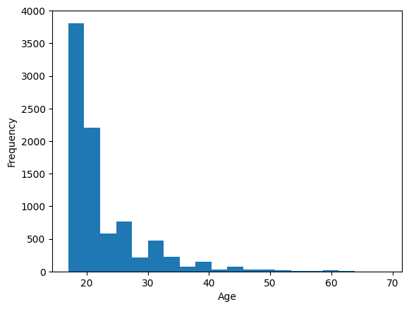

```python
# Histogram of age of participants
df_adult_learner_tidy['Eng_start'].plot.hist(xlabel='Age', bins=20)
df_adult_learner_tidy['Eng_start'].describe()
```

|  | age | Eng_start | yrs_learning |
| --- | --- | --- | --- |
| count | 8958.000000 | 8958.000000 | 8958.000000 |
| mean | 34.517080 | 22.235655 | 12.281424 |
| std | 10.841469 | 6.585781 | 9.718739 |
| min | 18.000000 | 17.000000 | 1.000000 |
| 25% | 26.000000 | 18.000000 | 5.000000 |
| 50% | 33.000000 | 20.000000 | 10.000000 |
| 75% | 40.000000 | 24.000000 | 17.000000 |
| max | 89.000000 | 69.000000 | 64.000000 |

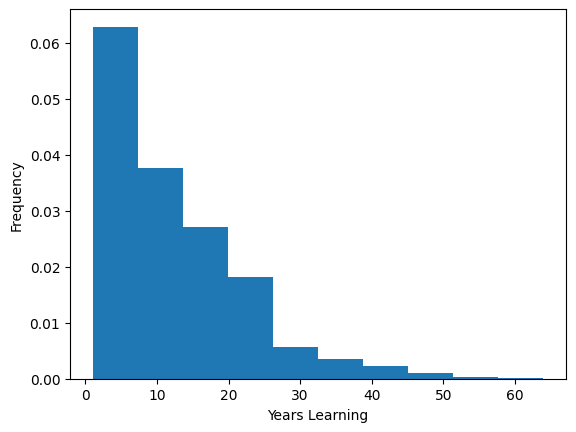

```python
df_adult_learner['yrs_learning'].plot.hist(bins=10, xlabel='Years Learning', density=True)
df_adult_learner[['age', 'Eng_start', 'yrs_learning']].describe()
```

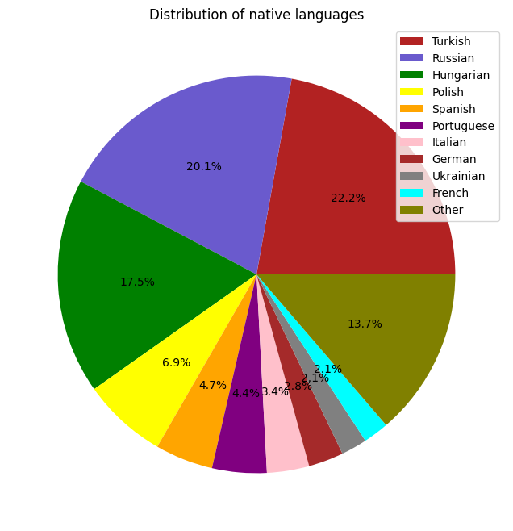

```python
# Pie chart showing the percentages of non-native adult English speakers in the dataset

df_natlang_other = pd.Series(df_adult_learner_tidy['natlang'].value_counts().iloc[10:].sum(), index=['Other'])
df_natlang_pie = pd.concat([df_adult_learner_tidy['natlang'].value_counts().iloc[0:10], df_natlang_other])

fig, ax = plt.subplots(figsize=(8, 8))
colors = ['firebrick', 'slateblue', 'green', 'yellow', 'orange', 'purple', 'pink', 'brown', 'gray', 'cyan', 'olive']

ax.pie(x=df_natlang_pie.values, labels=None, colors=colors, autopct='%1.1f%%')
plt.legend(df_natlang_pie.index, loc='best')
plt.title('Distribution of native languages')
plt.show()
```

# Features dataset

### **ETL**

```python
import glob

# Change to folder containing all additional CSVs:
%cd /content/drive/MyDrive/ColabNotebooks/additionalFiles


# Glob all csv files:
all_csvs = glob.glob('*.csv')

# Create base df for later merging:
df_features = pd.read_csv('genitive_noun.csv',sep='\t').drop(columns = ['description','value'])

# Iterate through list and merge dfs:
for file in all_csvs:
  # Print file name for debugging
  print(f"Processing file: {file}")

  # Read in current file and slice for non-redundant columns:
  df_current = pd.read_csv(file, sep='\t', on_bad_lines='skip')
  current_name = file[:-4] # Get name of file for df columns

  # Rename value and description columns
  df_current = df_current.rename(
      columns={
          "value": current_name + "_value",
          "description": current_name + "_description",
      }
  )

  # Select only the columns to merge
  df_current_sliced = df_current[['name', current_name + '_value', current_name + '_description']]

  # Perform the merge
  df_features = df_features.merge(df_current_sliced, on='name', how='outer')

# Drop unnecessary variables
df_features = df_features.drop(columns=['wals code', 'latitude', 'longitude', 'area'], errors='ignore') #ignore if column doesn't exist
```

```
/content/drive/MyDrive/ColabNotebooks/additionalFiles
Processing file: case_num.csv
Processing file: perfective_aspect.csv
Processing file: future_tense.csv
Processing file: indef_art.csv
Processing file: lang_order.csv
Processing file: past_tense.csv
Processing file: locus.csv
Processing file: inflection.csv
Processing file: perfect.csv
Processing file: neg_morpheme.csv
Processing file: polar_q.csv
Processing file: def_art.csv
Processing file: nominal_plurality.csv
Processing file: gender_distinctions.csv
Processing file: case_syncretism.csv
Processing file: number_of_genders.csv
Processing file: case_affixes.csv
Processing file: comitatives.csv
Processing file: adposition_noun.csv
Processing file: conjunctions.csv
Processing file: epistemic_possibility.csv
Processing file: third_person_prondem.csv
Processing file: relative_noun.csv
Processing file: tense_aspect.csv
Processing file: situational_possibility.csv
Processing file: numeral_classifiers.csv
Processing file: demonstrative_noun.csv
Processing file: passive_construction.csv
Processing file: polar_question_particles.csv
Processing file: ditransitive_constructions.csv
Processing file: genitive_noun.csv
Processing file: indefinite_pronouns.csv
```

We then checked for feature-based differences between Mandarin and Cantonese, aiming to simplify them into "Chinese," like in our first dataset. Since the two languages/dialects are fairly similar, we combined them. We also renamed a few inconsistencies.

```python
# Check for differences between Mandarin and Cantonese
mandarin = df_features[df_features['name'] == 'Mandarin'].reset_index(drop=True)
cantonese = df_features[df_features['name'] == 'Cantonese'].reset_index(drop=True)
display(mandarin.compare(cantonese))

# Combine Mandarin and Cantonese into a single observation, Chinese
df_features.loc[df_features['name'] == 'Mandarin', 'name'] = 'Chinese'
df_features.loc[df_features['name'] == 'Cantonese', 'name'] = 'Chinese'
df_features = df_features.groupby('name').first().reset_index()

# Rename other languages with inconsistent names between datasets
df_features['name'] = df_features['name'].str.replace(r'^Malay.*', 'Malay', regex=True)
df_features['name'] = df_features['name'].str.replace(r'^Greek.*', 'Greek', regex=True)
df_features['name'] = df_features['name'].str.replace(r'^Serbian.*', 'Serbian', regex=True)
```

|  | name self | name other | case_num_value self | case_num_value other | case_num_description self | case_num_description other | indef_art_value self | indef_art_value other | indef_art_description self | indef_art_description other | ... | passive_construction_description self | passive_construction_description other | polar_question_particles_value self | polar_question_particles_value other | polar_question_particles_description self | polar_question_particles_description other | indefinite_pronouns_value self | indefinite_pronouns_value other | indefinite_pronouns_description self | indefinite_pronouns_description other |
| --- | --- | --- | --- | --- | --- | --- | --- | --- | --- | --- | --- | --- | --- | --- | --- | --- | --- | --- | --- | --- | --- |
| 0 | Mandarin | Cantonese | 1.0 | NaN | No morphological case-marking | NaN | NaN | 2.0 | NaN | Indefinite word same as 'one' | ... | Present | NaN | 2.0 | NaN | Final | NaN | 4.0 | 3.0 | Mixed | Special |

1 rows × 62 columns

Because in the WALS dataset (and not the original dataset), Arabic is broken up by regional dialect, and each dialect is significantly different grammatically, we unfortunately have to drop it:

```python
df_features.drop(df_features[df_features['name'] == 'Arabic'].index, inplace=True)
df_adult_learner_tidy.drop(df_adult_learner_tidy[df_adult_learner_tidy['natlang'] == 'Arabic'].index, inplace=True)
```

We then merge the new dataframe with the dataframe from the previous section:

```python
# Merge df_features with df_adult_learner on natlang
df_features = df_features.rename(columns={'name':'natlang'})
df_adult_learner_tidy = df_adult_learner_tidy.merge(df_features, how='left', on='natlang')
```

### **EDA**

We were interested in the distribution of language families in the dataset:

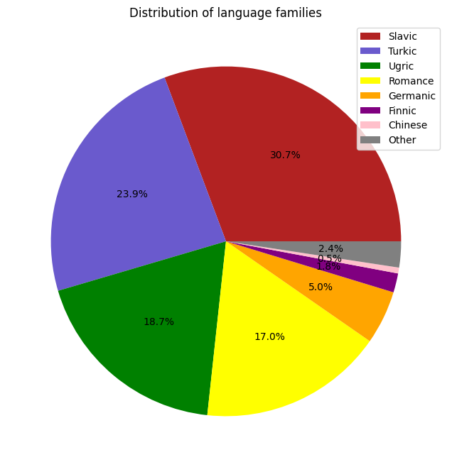

```python
df_genus_other = pd.Series(df_adult_learner_tidy['genus'].value_counts().iloc[7:].sum(), index=['Other'])
df_genus_pie = pd.concat([df_adult_learner_tidy['genus'].value_counts().iloc[0:7], df_genus_other])

fig, ax = plt.subplots(figsize=(8, 8))
colors = ['firebrick', 'slateblue', 'green', 'yellow', 'orange', 'purple', 'pink', 'gray']

ax.pie(x=df_genus_pie.values, labels=None, colors=colors, autopct='%1.1f%%')
ax.set_title('Distribution of language families')
plt.legend(df_genus_pie.index, loc='best')
plt.show()
```

What are the distributions of particular languages within each language family represented here?

```python
df_adult_learner_tidy.groupby('genus')['natlang'].value_counts().sort_values(ascending=False)
```

| genus | natlang | count |
| --- | --- | --- |
| Turkic | Turkish | 1930 |
| Slavic | Russian | 1750 |
| Ugric | Hungarian | 1526 |
| Slavic | Polish | 600 |
| Romance | Spanish | 411 |
|  | Portuguese | 386 |
|  | Italian | 299 |
| Germanic | German | 248 |
| Romance | French | 181 |
| Finnic | Finnish | 91 |
| Romance | Romanian | 88 |
| Slavic | Czech | 82 |
| Germanic | English | 72 |
| Finnic | Estonian | 53 |
| Germanic | Dutch | 47 |
| Chinese | Chinese | 44 |
| Slavic | Bulgarian | 34 |
|  | Serbian | 33 |
| Greek | Greek | 25 |
| Vietic | Vietnamese | 24 |
| Germanic | Swedish | 24 |
| Romance | Catalan | 23 |
| Baltic | Lithuanian | 22 |
| Japanese | Japanese | 20 |
| Korean | Korean | 15 |
| Baltic | Latvian | 14 |
| Kartvelian | Georgian | 13 |
| Malayo-Sumbawan | Indonesian | 13 |
| Turkic | Tatar | 8 |
| Germanic | Norwegian | 7 |
| Indic | Hindi | 7 |
| Albanian | Albanian | 6 |
| Kam-Tai | Thai | 5 |
| Turkic | Turkmen | 5 |
| Dravidian | Tamil | 4 |
| Germanic | Icelandic | 3 |
| Indic | Urdu | 3 |
| Slavic | Macedonian | 3 |
| Germanic | Danish | 3 |
| Basque | Basque | 3 |
| Ainu | Ainu | 2 |
| Wolof | Wolof | 2 |
| Northwest Caucasian | Abkhaz | 2 |
| Khmer | Khmer | 2 |
| Greater Central Philippine | Tagalog | 2 |
| Dravidian | Telugu | 2 |
| Bantu | Swahili | 2 |
| Nakh | Chechen | 1 |
| Lowland East Cushitic | Somali | 1 |
| Indic | Marathi | 1 |
| Southern Iroquoian | Cherokee | 1 |
| Dravidian | Kannada | 1 |
| Celtic | Irish | 1 |
| Turkic | Uzbek | 1 |
| Athapaskan | Navajo | 1 |
| Kam-Tai | Lao | 1 |

**dtype:** int64

We then computed a distance matrix to determine which languages were grammatically closest to English based on these features.

```python
# Add English speakers back to the dataframe, creating the dataframe for our sample

df_lang_eng = df_lang[df_lang['natlangs'] == 'English']
df_lang_eng = df_lang_eng.rename(columns={'natlangs':'natlang'})
df_lang_sample = df_adult_learner_tidy.merge(df_lang_eng, how='outer')
```

```python
from sklearn.metrics import pairwise_distances
from sklearn.preprocessing import StandardScaler
from sklearn.impute import KNNImputer

# For visualization, filter by the top 30 most common languages in the dataset
df_lang_30_index = df_lang_sample['natlang'].value_counts()[:30].index
df_features = df_features[df_features['natlang'].isin(df_lang_30_index)]

# Dummify feature variables
df_features_desc = df_features.filter(regex='_description$')
df_features_encode = pd.get_dummies(df_features_desc)

# Apply KNN imputation
imputer = KNNImputer(n_neighbors=5)
df_features_imputed = imputer.fit_transform(df_features_encode)

# Convert imputed array back to DataFrame
df_features_desc = pd.DataFrame(df_features_imputed, columns=df_features_encode.columns, index=df_features_desc.index)

# Standardize data
scaler = StandardScaler()
scaler.fit(df_features_encode)
df_features_sc = scaler.transform(df_features_encode)

# Create the distance matrix
D = pairwise_distances(df_features_encode, metric='euclidean')
np.fill_diagonal(D, np.nan)
df_features_sc = pd.DataFrame(D, index=df_features['natlang'], columns=df_features['natlang'])
display(df_features_sc)
```

| natlang | Bulgarian | Catalan | Chinese | Czech | Dutch | English | Estonian | Finnish | French | German | ... | Polish | Portuguese | Romanian | Russian | Serbian | Spanish | Swedish | Turkish | Ukrainian | Vietnamese |
| --- | --- | --- | --- | --- | --- | --- | --- | --- | --- | --- | --- | --- | --- | --- | --- | --- | --- | --- | --- | --- | --- |
| Bulgarian | NaN | 4.472136 | 5.477226 | 4.472136 | 4.582576 | 5.000000 | 4.358899 | 5.291503 | 5.000000 | 5.477226 | ... | 4.582576 | 3.741657 | 4.582576 | 4.795832 | 4.472136 | 4.898979 | 4.582576 | 6.164414 | 3.872983 | 5.291503 |
| Catalan | 4.472136 | NaN | 5.656854 | 4.000000 | 3.872983 | 5.196152 | 4.358899 | 5.830952 | 4.795832 | 4.898979 | ... | 4.123106 | 3.741657 | 3.605551 | 5.196152 | 4.242641 | 4.472136 | 3.872983 | 6.164414 | 4.123106 | 5.291503 |
| Chinese | 5.477226 | 5.656854 | NaN | 6.324555 | 5.744563 | 6.403124 | 5.916080 | 6.000000 | 6.403124 | 6.633250 | ... | 5.916080 | 5.656854 | 6.244998 | 6.403124 | 6.000000 | 6.000000 | 5.744563 | 6.480741 | 5.916080 | 5.656854 |
| Czech | 4.472136 | 4.000000 | 6.324555 | NaN | 4.582576 | 5.385165 | 3.872983 | 5.477226 | 5.916080 | 5.477226 | ... | 4.123106 | 4.898979 | 4.795832 | 5.000000 | 3.741657 | 5.291503 | 4.582576 | 6.000000 | 3.316625 | 6.000000 |
| Dutch | 4.582576 | 3.872983 | 5.744563 | 4.582576 | NaN | 4.472136 | 5.099020 | 5.916080 | 5.099020 | 4.582576 | ... | 4.472136 | 4.358899 | 4.898979 | 5.477226 | 5.000000 | 4.123106 | 4.242641 | 6.557439 | 4.690416 | 5.567764 |
| English | 5.000000 | 5.196152 | 6.403124 | 5.385165 | 4.472136 | NaN | 5.830952 | 6.082763 | 5.477226 | 4.358899 | ... | 5.656854 | 5.000000 | 5.291503 | 5.656854 | 5.744563 | 5.385165 | 4.242641 | 7.000000 | 5.477226 | 6.403124 |
| Estonian | 4.358899 | 4.358899 | 5.916080 | 3.872983 | 5.099020 | 5.830952 | NaN | 4.795832 | 5.656854 | 5.744563 | ... | 3.741657 | 4.582576 | 4.690416 | 5.099020 | 3.605551 | 5.744563 | 4.690416 | 5.567764 | 2.828427 | 6.082763 |
| Finnish | 5.291503 | 5.830952 | 6.000000 | 5.477226 | 5.916080 | 6.082763 | 4.795832 | NaN | 5.916080 | 5.656854 | ... | 5.000000 | 5.656854 | 5.916080 | 5.196152 | 5.291503 | 5.656854 | 5.385165 | 6.164414 | 5.196152 | 6.164414 |
| French | 5.000000 | 4.795832 | 6.403124 | 5.916080 | 5.099020 | 5.477226 | 5.656854 | 5.916080 | NaN | 4.795832 | ... | 5.099020 | 4.358899 | 5.291503 | 5.099020 | 5.744563 | 3.872983 | 5.291503 | 5.916080 | 5.291503 | 6.403124 |
| German | 5.477226 | 4.898979 | 6.633250 | 5.477226 | 4.582576 | 4.358899 | 5.744563 | 5.656854 | 4.795832 | NaN | ... | 5.385165 | 4.690416 | 5.000000 | 5.000000 | 5.830952 | 4.898979 | 4.582576 | 6.633250 | 5.385165 | 6.480741 |
| Greek | 4.898979 | 4.898979 | 6.324555 | 5.656854 | 4.795832 | 5.385165 | 5.196152 | 5.830952 | 4.123106 | 4.000000 | ... | 4.582576 | 4.000000 | 4.582576 | 4.358899 | 5.291503 | 4.690416 | 5.000000 | 6.164414 | 4.582576 | 6.164414 |
| Hungarian | 5.567764 | 6.082763 | 6.855655 | 6.082763 | 5.477226 | 6.164414 | 5.099020 | 5.385165 | 6.164414 | 5.916080 | ... | 5.656854 | 5.567764 | 5.830952 | 5.656854 | 5.744563 | 6.082763 | 5.830952 | 5.385165 | 5.477226 | 6.557439 |
| Italian | 4.472136 | 2.828427 | 5.656854 | 4.690416 | 3.316625 | 4.582576 | 4.795832 | 5.830952 | 4.123106 | 4.472136 | ... | 4.358899 | 3.741657 | 4.123106 | 5.196152 | 4.898979 | 4.000000 | 4.123106 | 6.000000 | 4.582576 | 5.477226 |
| Japanese | 6.000000 | 6.480741 | 5.477226 | 6.164414 | 6.403124 | 6.708204 | 5.744563 | 5.830952 | 6.855655 | 6.633250 | ... | 5.916080 | 6.164414 | 6.403124 | 6.244998 | 6.164414 | 6.633250 | 6.244998 | 5.477226 | 5.916080 | 6.480741 |
| Lithuanian | 4.582576 | 4.358899 | 6.082763 | 3.605551 | 4.898979 | 5.830952 | 3.464102 | 5.000000 | 5.477226 | 5.744563 | ... | 2.828427 | 4.358899 | 4.690416 | 4.472136 | 3.605551 | 5.567764 | 4.690416 | 5.744563 | 2.828427 | 5.744563 |
| Polish | 4.582576 | 4.123106 | 5.916080 | 4.123106 | 4.472136 | 5.656854 | 3.741657 | 5.000000 | 5.099020 | 5.385165 | ... | NaN | 4.123106 | 4.472136 | 4.242641 | 3.605551 | 5.196152 | 4.898979 | 6.082763 | 2.828427 | 5.567764 |
| Portuguese | 3.741657 | 3.741657 | 5.656854 | 4.898979 | 4.358899 | 5.000000 | 4.582576 | 5.656854 | 4.358899 | 4.690416 | ... | 4.123106 | NaN | 3.605551 | 4.795832 | 4.690416 | 4.472136 | 3.872983 | 5.830952 | 4.123106 | 5.477226 |
| Romanian | 4.582576 | 3.605551 | 6.244998 | 4.795832 | 4.898979 | 5.291503 | 4.690416 | 5.916080 | 5.291503 | 5.000000 | ... | 4.472136 | 3.605551 | NaN | 4.898979 | 4.795832 | 5.000000 | 3.741657 | 6.082763 | 4.472136 | 5.916080 |
| Russian | 4.795832 | 5.196152 | 6.403124 | 5.000000 | 5.477226 | 5.656854 | 5.099020 | 5.196152 | 5.099020 | 5.000000 | ... | 4.242641 | 4.795832 | 4.898979 | NaN | 4.795832 | 5.385165 | 5.656854 | 6.403124 | 4.472136 | 6.244998 |
| Serbian | 4.472136 | 4.242641 | 6.000000 | 3.741657 | 5.000000 | 5.744563 | 3.605551 | 5.291503 | 5.744563 | 5.830952 | ... | 3.605551 | 4.690416 | 4.795832 | 4.795832 | NaN | 5.477226 | 5.000000 | 6.324555 | 3.316625 | 5.656854 |
| Spanish | 4.898979 | 4.472136 | 6.000000 | 5.291503 | 4.123106 | 5.385165 | 5.744563 | 5.656854 | 3.872983 | 4.898979 | ... | 5.196152 | 4.472136 | 5.000000 | 5.385165 | 5.477226 | NaN | 4.358899 | 6.324555 | 5.385165 | 6.164414 |
| Swedish | 4.582576 | 3.872983 | 5.744563 | 4.582576 | 4.242641 | 4.242641 | 4.690416 | 5.385165 | 5.291503 | 4.582576 | ... | 4.898979 | 3.872983 | 3.741657 | 5.656854 | 5.000000 | 4.358899 | NaN | 6.244998 | 4.690416 | 5.916080 |
| Turkish | 6.164414 | 6.164414 | 6.480741 | 6.000000 | 6.557439 | 7.000000 | 5.567764 | 6.164414 | 5.916080 | 6.633250 | ... | 6.082763 | 5.830952 | 6.082763 | 6.403124 | 6.324555 | 6.324555 | 6.244998 | NaN | 5.916080 | 7.071068 |
| Ukrainian | 3.872983 | 4.123106 | 5.916080 | 3.316625 | 4.690416 | 5.477226 | 2.828427 | 5.196152 | 5.291503 | 5.385165 | ... | 2.828427 | 4.123106 | 4.472136 | 4.472136 | 3.316625 | 5.385165 | 4.690416 | 5.916080 | NaN | 5.744563 |
| Vietnamese | 5.291503 | 5.291503 | 5.656854 | 6.000000 | 5.567764 | 6.403124 | 6.082763 | 6.164414 | 6.403124 | 6.480741 | ... | 5.567764 | 5.477226 | 5.916080 | 6.244998 | 5.656854 | 6.164414 | 5.916080 | 7.071068 | 5.744563 | NaN |

25 rows × 25 columns

Since the distance matrix is hard to read, we created a heatmap to visualize our data.

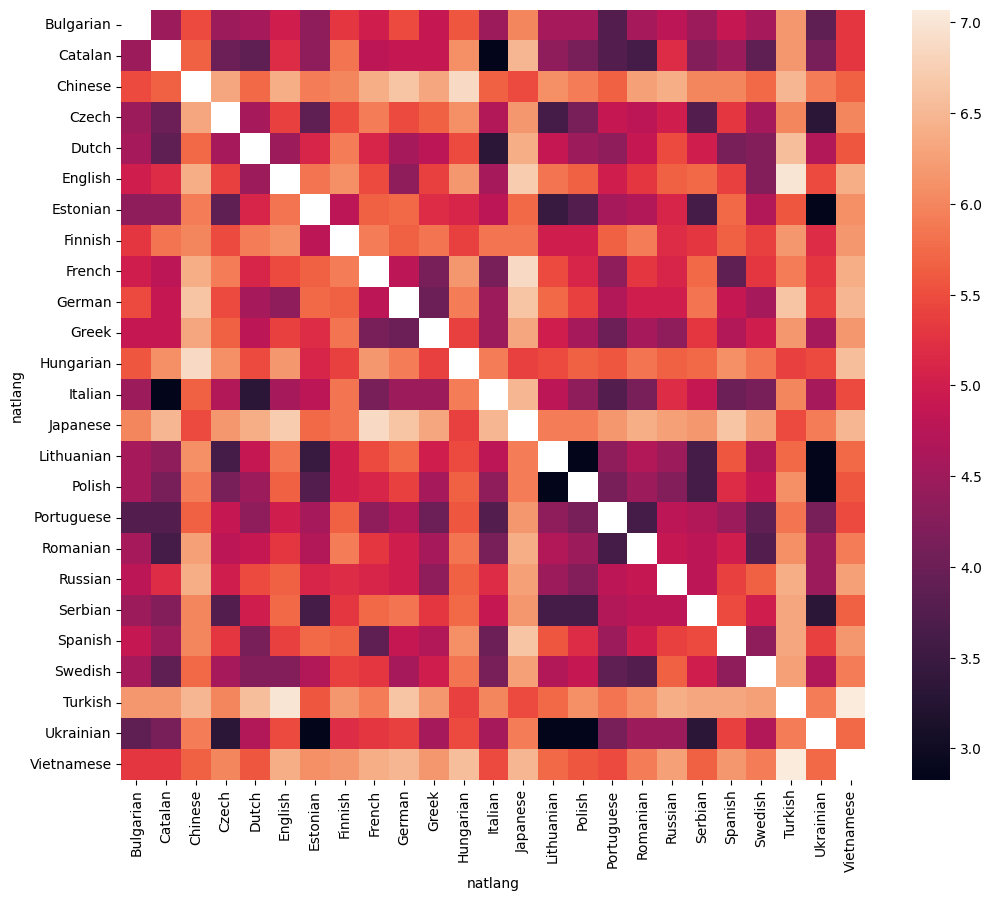

```python
import seaborn as sns

plt.figure(figsize=(12, 10))
sns.heatmap(df_features_sc)
sns.set(font_scale=1.2)
```

We then observed each language's distance from English based on the syntactic features. There were some surprising languages due to the relatively small number of features included, but the distances lined up with our intuitions overall.

```python
# Slice DataFrame for distances from English
df_eng_dist = df_features_sc['English'].sort_values()
display(df_eng_dist)
```

| natlang | English |
| --- | --- |
| Swedish | 4.242641 |
| German | 4.358899 |
| Dutch | 4.472136 |
| Italian | 4.582576 |
| Portuguese | 5.000000 |
| Bulgarian | 5.000000 |
| Catalan | 5.196152 |
| Romanian | 5.291503 |
| Czech | 5.385165 |
| Greek | 5.385165 |
| Spanish | 5.385165 |
| French | 5.477226 |
| Ukrainian | 5.477226 |
| Polish | 5.656854 |
| Russian | 5.656854 |
| Serbian | 5.744563 |
| Lithuanian | 5.830952 |
| Estonian | 5.830952 |
| Finnish | 6.082763 |
| Hungarian | 6.164414 |
| Chinese | 6.403124 |
| Vietnamese | 6.403124 |
| Japanese | 6.708204 |
| Turkish | 7.000000 |
| English | NaN |

**dtype:** float64

Is there a relationship between syntactic similarity to English and overall test performance among adult non-Native English speakers?

|  | Distance | correct |
| --- | --- | --- |
| Distance | 1.000000 | -0.430582 |
| correct | -0.430582 | 1.000000 |

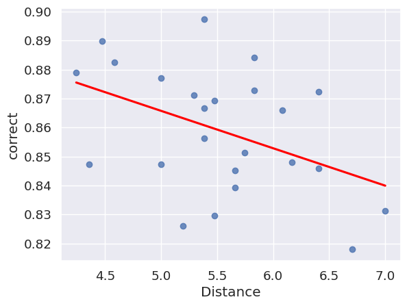

```python
df_lang_30 = df_lang_sample[df_lang_sample['natlang'].isin(df_lang_30_index)]
df_30_correct = df_lang_30.groupby('natlang')['correct'].mean().sort_values(ascending=False)

# Organize alphabetically to have the same index
df_eng_dist = df_eng_dist.sort_index()
df_30_correct = df_30_correct.sort_index()

# Concatenate the two Series and sort
df_eng_dist_concat = pd.DataFrame(df_eng_dist).merge(df_30_correct,how='left',on='natlang')
df_eng_dist_concat = df_eng_dist_concat.rename(columns={'English': 'Distance'})
df_eng_dist_concat = df_eng_dist_concat.sort_values(by = 'Distance')
df_eng_dist_concat = df_eng_dist_concat.drop('English')

# Create plot
sns.regplot(x='Distance', y='correct', data=df_eng_dist_concat, ci=None, line_kws={'color': 'red'})
df_eng_dist_concat.corr()
```

There is a moderately strong relationship between syntactic similarity to English and overall test performance, which is surprising since we aren't controlling for any other variables.

While there are clearly some languages that are more similar than others, as visible on the distance matrix, we decided to use K means clustering to be more certain of the groups of languages. We experimented with several different numbers of clusters, but decided on 4.

```python
from sklearn.cluster import KMeans

kmeans = KMeans(n_clusters=4)

# Fit the model to the data
df_eng_dist_concat = df_eng_dist_concat.fillna(0)
kmeans.fit(df_eng_dist_concat)

# Get the cluster labels for each data point
labels = kmeans.labels_

# Add the labels to the dataframe
df_eng_dist_concat['cluster'] = labels
df_eng_dist_concat.sort_values(by='cluster')
```

| natlang | Distance | correct | cluster |
| --- | --- | --- | --- |
| French | 5.477226 | 0.869148 | 0 |
| Ukrainian | 5.477226 | 0.829519 | 0 |
| Portuguese | 5.000000 | 0.847178 | 0 |
| Bulgarian | 5.000000 | 0.877090 | 0 |
| Catalan | 5.196152 | 0.826087 | 0 |
| Romanian | 5.291503 | 0.871172 | 0 |
| Czech | 5.385165 | 0.866752 | 0 |
| Greek | 5.385165 | 0.897263 | 0 |
| Spanish | 5.385165 | 0.856192 | 0 |
| Vietnamese | 6.403124 | 0.872368 | 1 |
| Chinese | 6.403124 | 0.845933 | 1 |
| Turkish | 7.000000 | 0.831274 | 1 |
| Japanese | 6.708204 | 0.817895 | 1 |
| Italian | 4.582576 | 0.882450 | 2 |
| Dutch | 4.472136 | 0.889810 | 2 |
| German | 4.358899 | 0.847284 | 2 |
| Swedish | 4.242641 | 0.878947 | 2 |
| Polish | 5.656854 | 0.845193 | 3 |
| Russian | 5.656854 | 0.839218 | 3 |
| Serbian | 5.744563 | 0.851356 | 3 |
| Lithuanian | 5.830952 | 0.884211 | 3 |
| Estonian | 5.830952 | 0.872691 | 3 |
| Finnish | 6.082763 | 0.866050 | 3 |
| Hungarian | 6.164414 | 0.848093 | 3 |

```python
# Merge df_PCA with df_lang_sample
df_lang_sample = df_lang_sample.merge(df_eng_dist_concat.drop(columns='correct'), how='left', on='natlang')
```

To better visualize each language's distance from English, as well as how close they are to other languages, we used principle component analysis (PCA) to reduce the number of dimensions to 2.

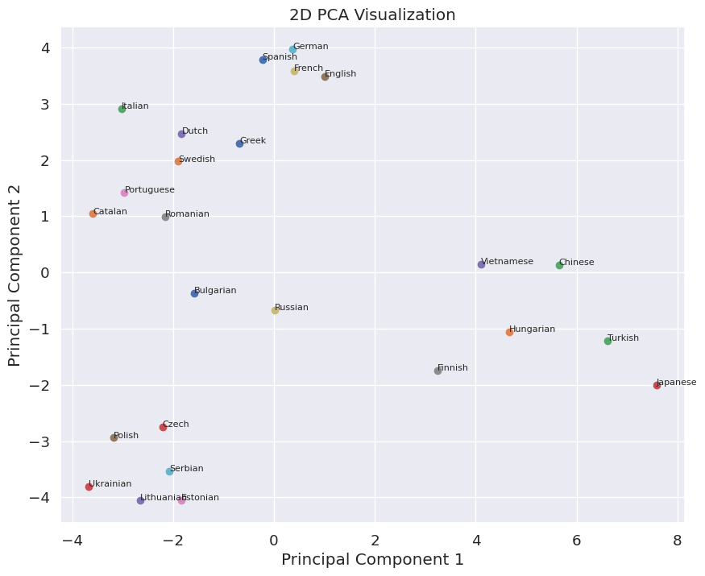

```python
from sklearn.decomposition import PCA

plt.figure(figsize=(10, 8))

pca = PCA(n_components=2)

# Fit the PCA model to the scaled data
df_features_sc = df_features_sc.fillna(0)
principal_components = pca.fit_transform(df_features_sc)

# Create a DataFrame with the principal components
df_PCA = pd.DataFrame(data=principal_components, columns=['PC1', 'PC2'])

# Plot results
plt.figure(figsize=(10, 8))  # Adjust figure size if needed

# Scatter plot with labels
for i, language in enumerate(df_features['natlang']):
    x = df_PCA.loc[i, 'PC1']
    y = df_PCA.loc[i, 'PC2']
    plt.scatter(x, y)
    plt.text(x, y, language, fontsize=8)

plt.xlabel('Principal Component 1')
plt.ylabel('Principal Component 2')
plt.title('2D PCA Visualization')
plt.show()
```

In the subsequent analysis, we will use the clusters in the unreduced dimensional space for better interpretability. At first glance, we only saw slight differences in performance by cluster:

```python
# How many people are in each cluster
cluster_counts = df_lang_sample['cluster'].value_counts()
display(cluster_counts)

# Use stratified random sampling to make each cluster size roughly equal
df_lang_sample = df_lang_sample.drop(df_lang_sample[df_lang_sample['natlang']=='English'].index)

df_lang_sample = df_lang_sample.drop(df_lang_sample[df_lang_sample['cluster'] == 0].sample(frac=((3511-618)/3511), random_state=1).index)
df_lang_sample = df_lang_sample.drop(df_lang_sample[df_lang_sample['cluster'] == 2].sample(frac=((2018-618)/2018), random_state=1).index)
df_lang_sample = df_lang_sample.drop(df_lang_sample[df_lang_sample['cluster'] == 3].sample(frac=((2014-618)/2014), random_state=1).index)
```

| cluster | count |
| --- | --- |
| 3.0 | 4075 |
| 1.0 | 2018 |
| 0.0 | 1414 |
| 2.0 | 618 |

**dtype:** int64

| cluster | correct |
| --- | --- |
| 0.0 | 0.853477 |
| 1.0 | 0.831949 |
| 2.0 | 0.864996 |
| 3.0 | 0.843326 |

**dtype:** float64

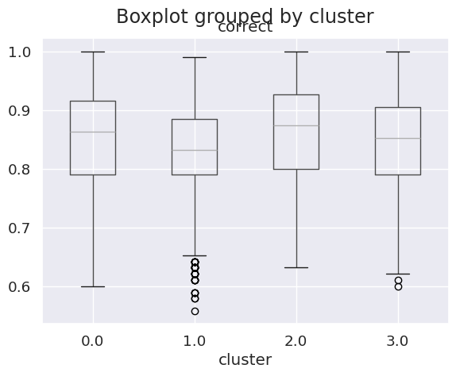

```python
# Create boxplots
df_lang_sample.boxplot(column='correct', by='cluster')

# Compare mean scores
df_lang_sample.groupby('cluster')['correct'].mean()
```

```python
import statsmodels.formula.api as sm
from statsmodels.stats.anova import anova_lm

# ANOVA
model = sm.ols(formula='correct ~ C(cluster)', data=df_lang_sample).fit()
anova_table = anova_lm(model, typ=2)
anova_table

# Post hoc tests
from statsmodels.stats.multicomp import pairwise_tukeyhsd
tukey_results = pairwise_tukeyhsd(df_lang_sample['correct'], df_lang_sample['cluster'])
print(tukey_results)
```

```
Multiple Comparison of Means - Tukey HSD, FWER=0.05
====================================================
group1 group2 meandiff p-adj   lower   upper  reject
----------------------------------------------------
   0.0    1.0  -0.0215 0.0004 -0.0358 -0.0073   True
   0.0    2.0   0.0115 0.5381 -0.0089   0.032  False
   0.0    3.0  -0.0102 0.3265 -0.0249  0.0046  False
   0.0    nan  -0.0229 0.0017 -0.0396 -0.0063   True
   1.0    2.0    0.033    0.0  0.0169  0.0492   True
   1.0    3.0   0.0114 0.0005  0.0037   0.019   True
   1.0    nan  -0.0014 0.9968 -0.0124  0.0096  False
   2.0    3.0  -0.0217 0.0033 -0.0382 -0.0051   True
   2.0    nan  -0.0344    0.0 -0.0528 -0.0161   True
   3.0    nan  -0.0128 0.0216 -0.0243 -0.0012   True
----------------------------------------------------
```

However, this analysis overlooks whether there are significant differences between clusters in performance on each question. As the graph below shows, the clusters seem to respond relatively similarly to each question and no one cluster is apparently worse, but there is still some variation at the level of a single question:

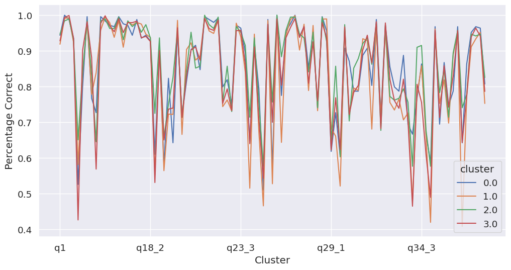

```python
# Create index of each question column
question_index = df_lang_sample.columns[pd.Series(df_lang_sample.columns).str.startswith('q')]

# Create empty list
df_questions = pd.DataFrame()

# Iterate through questions to find correct % for each question based on clusters
for question in question_index:
  clust = df_lang_sample.groupby('cluster')[question].mean()
  df_questions = pd.concat([df_questions, clust],axis=1)

df_questions = df_questions.reset_index()
df_questions = df_questions.rename(columns={'index': 'cluster'})
df_questions = df_questions.melt(id_vars=['cluster'])

# Create barplot comparing scores of different clusters on questions
fig, ax = plt.subplots(figsize=(12, 6))
df_questions_pivot = df_questions.pivot_table(index='variable', columns='cluster', values='value')
df_questions_pivot.plot(kind='line', ax=ax)
plt.xlabel('Cluster')
plt.ylabel('Percentage Correct')
plt.show()
```

We performed another ANOVA to officially test for differences in test question performance among groups.

```python
model = sm.ols(formula='value ~ C(cluster)', data=df_questions).fit()
anova_table = anova_lm(model, typ=2)
anova_table
```

|  | sum_sq | df | F | PR(>F) |
| --- | --- | --- | --- | --- |
| C(cluster) | 0.056768 | 3.0 | 0.990829 | 0.397095 |
| Residual | 7.180805 | 376.0 | NaN | NaN |

This table shows that there are not significant differences in the performance on each of the 95 test questions. This isn't great news for the model that we will build in the next section, but we will still try it out. While we could restrict our model to just the questions that the clusters answer most differently, this could artificially improve the model -- it may just be that the four clusters do not perform differently systematically.

# **Modeling**

In the final section of this project, we create a k-nearest neighbors classifier to predict a given participant's language cluster based on their answers to the test questions.

```python
from sklearn.neighbors import KNeighborsClassifier

df_model = pd.concat([df_lang_sample[['cluster','natlang']],df_lang_sample[question_cols]],axis=1)

df_model = df_model.dropna()

# Split data into training and validation sets
x_train = df_model.drop(columns=['cluster','natlang']).sample(frac=.5, random_state=1)
y_train = df_model['cluster'].sample(frac=.5, random_state=1).dropna()

x_test = df_model.drop(columns=['cluster','natlang']).drop(x_train.index)
y_test = df_model['cluster'].drop(x_train.index)

# Standardize the data
scaler = StandardScaler()
scaler.fit(x_train)
x_train_sc = scaler.transform(x_train)
x_test_sc = scaler.transform(x_test)

def knnclass(k):
  # Fit the k-nearest neighbors model
  model = KNeighborsClassifier(n_neighbors=k)
  model.fit(x_train_sc, y_train)

  #predict the training data
  y_train_pred = model.predict(x_train_sc)

  #predict the validation data
  y_test_pred = model.predict(x_test_sc)

  confusion_mat = pd.crosstab(y_test, y_test_pred)
  confusion_mat = confusion_mat.reindex(columns=range(0,4)) #ensures that the confusion matrix has the correct dimensions
  confusion_mat = confusion_mat.fillna(0) # replace NaNs from line above

  accuracy = np.diag(confusion_mat).sum() / confusion_mat.to_numpy().sum()

  return accuracy

# Test the model for varying values of k
ks = range(1,100)
accuracies = [knnclass(k) for k in ks]
```

|  | 0 |
| --- | --- |
| 69 | 0.635186 |
| 71 | 0.635186 |
| 70 | 0.633567 |
| 72 | 0.631409 |
| 74 | 0.630329 |
| ... | ... |
| 4 | 0.558014 |
| 3 | 0.549379 |
| 2 | 0.524015 |
| 0 | 0.491096 |
| 1 | 0.476525 |

99 rows × 1 columns

**dtype:** float64

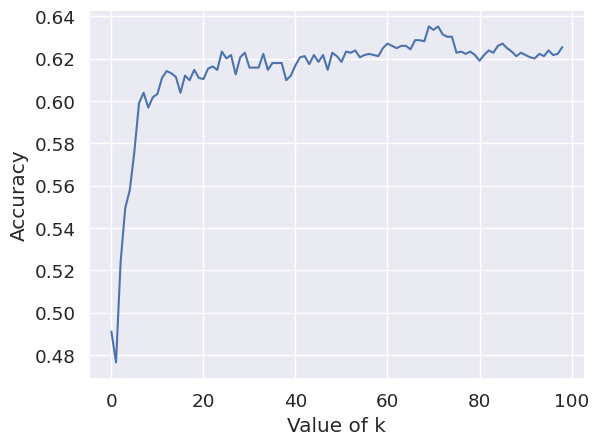

```python
knn_vals = pd.Series(accuracies).sort_values(ascending=False)

display(knn_vals)
plt.plot(accuracies)
plt.xlabel('Value of k')
plt.ylabel('Accuracy')
```

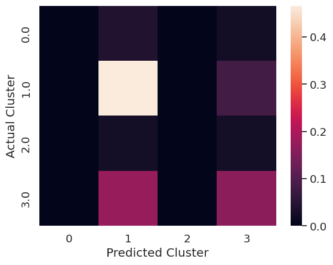

```python
# Fit the k-nearest neighbors model
model = KNeighborsClassifier(n_neighbors=69)
model.fit(x_train_sc, y_train)

# Predict the training data
y_train_pred = model.predict(x_train_sc)

# Predict the validation data
y_test_pred = model.predict(x_test_sc)

confusion_mat = pd.crosstab(y_test, y_test_pred)
confusion_mat = confusion_mat.reindex(columns=range(0,4))
confusion_mat = confusion_mat.fillna(0)
confusion_mat = confusion_mat / confusion_mat.sum().sum()

confusion_mat = confusion_mat.rename_axis('Predicted Cluster', axis='columns')
confusion_mat = confusion_mat.rename_axis('Actual Cluster', axis='rows')

sns.heatmap(confusion_mat)
```

```python
# Measuring the success of the model

true_pos = np.diag(confusion_mat).sum()
false_pos = (confusion_mat.sum(axis=0) - np.diag(confusion_mat))
false_neg = (confusion_mat.sum(axis=1) - np.diag(confusion_mat))

# Assess the precision, recall, and f-score of the model
precision = true_pos / (true_pos + false_pos)
recall = true_pos / (true_pos + false_neg)
f_score = precision * recall / (precision + recall)

precision = precision.rename('Precision').rename_axis(index=None)
recall = recall.rename('Recall').rename_axis(index=None)
f_score = f_score.rename('F-Score').rename_axis(index=None)

pd.concat([precision,recall,f_score],axis=1).rename_axis(index='Cluster')
```

| Cluster | Precision | Recall | F-Score |
| --- | --- | --- | --- |
| 0.0 | 1.000000 | 0.907249 | 0.475685 |
| 1.0 | 0.722084 | 0.884498 | 0.397541 |
| 2.0 | 1.000000 | 0.926752 | 0.480992 |
| 3.0 | 0.828470 | 0.781208 | 0.402073 |

It may be that grouping into just 4 clusters obscured some real differences between individual languages. In a future analysis, a classifier could be used to predict native language from test answers.

# **Conclusion**